# Prediction problems: Report

## Instructions

1. This is the template you may use to submit your code and report for the prediction problems on Kaggle.
2. You may modify the template if you deem fit, but it should have the information asked below.

## A.1) Data cleaning

Mention the data cleaning steps taken to prepare your data for developing the model. This may include imputing missing values, dealing with outliers, combining levels of categorical variable(s), etc.

- Imputed missing values with k-nearest neighbors, k = 7
- Removed features with only one value (zero-variance features)

```python
import math
import pandas as pd
import numpy as np
import matplotlib.pyplot as plt
import seaborn as sns
from statsmodels.stats.outliers_influence import variance_inflation_factor
from statsmodels.tools.tools import add_constant
from sklearn.ensemble import RandomForestRegressor
from sklearn.preprocessing import StandardScaler
from sklearn.model_selection import train_test_split, KFold, GridSearchCV, RandomizedSearchCV
from sklearn.metrics import mean_squared_error
from sklearn.impute import KNNImputer
from catboost import CatBoostRegressor
from lightgbm import LGBMRegressor
from xgboost import XGBRegressor
import time
from pyearth import Earth
from sklearn.ensemble import VotingRegressor, VotingClassifier, StackingRegressor, StackingClassifier, GradientBoostingRegressor,GradientBoostingClassifier, BaggingRegressor,BaggingClassifier,RandomForestRegressor,RandomForestClassifier,AdaBoostRegressor,AdaBoostClassifier
from sklearn.linear_model import LinearRegression,LogisticRegression, LassoCV, RidgeCV, ElasticNetCV
```

```python
# Read the data
train = pd.read_csv('train.csv')
train.head()
```

|  | id | x001 | x002 | x003 | x004 | x005 | x006 | x007 | x008 | x009 | ... | x757 | x758 | x759 | x760 | x761 | x762 | x763 | x764 | x765 | y |
| --- | --- | --- | --- | --- | --- | --- | --- | --- | --- | --- | --- | --- | --- | --- | --- | --- | --- | --- | --- | --- | --- |
| 0 | 0 | 9.681860e+10 | 6991.15 | 7.76 | 0.00380 | 5.378811e+09 | 0.31 | 266117.20 | 934577.0 | 14539.0 | ... | 0.0007 | 297281012 | 0.13 | 5.0 | 5 | 2.0 | 8.5127 | 14.28 | -0.75 | 5 |
| 1 | 1 | 3.304810e+09 | 13914.43 | 5.37 | 0.00015 | 1.652405e+09 | 0.00 | 11927742.92 | 1798051.0 | 1051272.0 | ... | 0.1136 | 3320000000000 | 0.08 | 661.0 | 0 | 350.0 | 1.5700 | 160.12 | NaN | 1 |
| 2 | 2 | 3.218944e+10 | 3991.98 | 5.77 | 0.00010 | 2.476111e+09 | 0.00 | 774385.01 | 375738.0 | 144143.0 | ... | 0.0029 | 100474819 | 0.39 | 39.0 | 2 | 18.0 | 9.6800 | 25.06 | -0.49 | 11 |
| 3 | 3 | 1.288000e+10 | 15937.45 | 5.86 | 0.00020 | 2.146667e+09 | 0.00 | 6324375.16 | 1932094.0 | 10055.0 | ... | 0.0000 | 348000000000 | 0.25 | 2.0 | 1 | 0.0 | 4.5316 | 117.76 | 1.64 | 1 |
| 4 | 4 | 3.063412e+10 | 3621.00 | 7.52 | 0.00060 | 1.392460e+09 | 0.21 | 169860.29 | 474253.0 | 17914.0 | ... | 0.0005 | 109546590 | 0.11 | 11.0 | 1 | 3.0 | 16.2717 | 5.81 | -0.42 | 5 |

5 rows × 767 columns

```python
X = train.drop(['id', 'y'], axis=1)
y = train['y']
X.shape
```

```
(5380, 765)
```

```python
imputer = KNNImputer(n_neighbors=7)
X_imputed = pd.DataFrame(imputer.fit_transform(X), columns=X.columns)
print(X_imputed.shape)
print(X_imputed.isna().sum().sum())
X_imputed.head()
```

```
(5380, 765)
0
```

|  | x001 | x002 | x003 | x004 | x005 | x006 | x007 | x008 | x009 | x010 | ... | x756 | x757 | x758 | x759 | x760 | x761 | x762 | x763 | x764 | x765 |
| --- | --- | --- | --- | --- | --- | --- | --- | --- | --- | --- | --- | --- | --- | --- | --- | --- | --- | --- | --- | --- | --- |
| 0 | 9.681860e+10 | 6991.15 | 7.76 | 0.00380 | 5.378811e+09 | 0.31 | 266117.20 | 934577.0 | 14539.0 | 2.690000e+13 | ... | 1.5707 | 0.0007 | 2.972810e+08 | 0.13 | 5.0 | 5.0 | 2.0 | 8.5127 | 14.28 | -0.750000 |
| 1 | 3.304810e+09 | 13914.43 | 5.37 | 0.00015 | 1.652405e+09 | 0.00 | 11927742.92 | 1798051.0 | 1051272.0 | 1.690000e+17 | ... | 0.1173 | 0.1136 | 3.320000e+12 | 0.08 | 661.0 | 0.0 | 350.0 | 1.5700 | 160.12 | 4.814286 |
| 2 | 3.218944e+10 | 3991.98 | 5.77 | 0.00010 | 2.476111e+09 | 0.00 | 774385.01 | 375738.0 | 144143.0 | 1.350000e+14 | ... | 0.4582 | 0.0029 | 1.004748e+08 | 0.39 | 39.0 | 2.0 | 18.0 | 9.6800 | 25.06 | -0.490000 |
| 3 | 1.288000e+10 | 15937.45 | 5.86 | 0.00020 | 2.146667e+09 | 0.00 | 6324375.16 | 1932094.0 | 10055.0 | 3.700000e+16 | ... | 0.3816 | 0.0000 | 3.480000e+11 | 0.25 | 2.0 | 1.0 | 0.0 | 4.5316 | 117.76 | 1.640000 |
| 4 | 3.063412e+10 | 3621.00 | 7.52 | 0.00060 | 1.392460e+09 | 0.21 | 169860.29 | 474253.0 | 17914.0 | 6.000000e+12 | ... | 0.0100 | 0.0005 | 1.095466e+08 | 0.11 | 11.0 | 1.0 | 3.0 | 16.2717 | 5.81 | -0.420000 |

5 rows × 765 columns

```python
zero_var = []
for col in X_imputed.columns:
    if (len(X_imputed[col].unique()) < 2):
        print(col, '\n', X_imputed[col].unique())
        zero_var.append(col)
print(len(zero_var))
```

```
x063
 [0.]
x137
 [0.]
x255
 [0.]
x385
 [0.]
x405
 [1.]
x453
 [1.]
x465
 [0.]
x518
 [0.]
x594
 [0.]
x643
 [0.]
x703
 [0.]
11
```

```python
X_imputed.drop(zero_var, axis=1, inplace=True)
X_imputed.shape
```

```
(5380, 754)
```

## A.2) Exploratory data analysis

Mention any major insights you obtained from the data, which you used to develop the model. PLease put your code or visualizations here if needed.

- Given the anonymization and size of the features, EDA was largely infeasible.
- Plotting the distribution of target values revealed a largely right-skewed distribution, motivationg a log transformation to normalize the target values for training.
- I identified 2 binary features and 1 categorical feature, but a clear relationship was not established between them and the response.

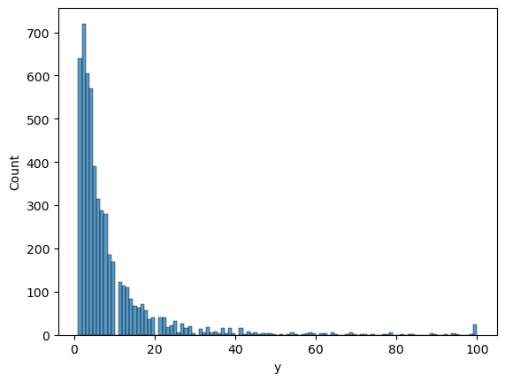

```python
sns.histplot(y)
plt.show()
```

```python
y_log = np.log(y)
```

```python
cat_nonbin = []
for col in X_imputed.columns:
    if (len(X_imputed[col].unique()) < 8):
        print(col, '\n', X_imputed[col].unique())
        cat_nonbin.append(col)
print(len(cat_nonbin))
```

```
x025
 [6. 2. 1. 5. 0. 3. 4.]
x516
 [0. 1.]
x556
 [1. 0.]
3
```

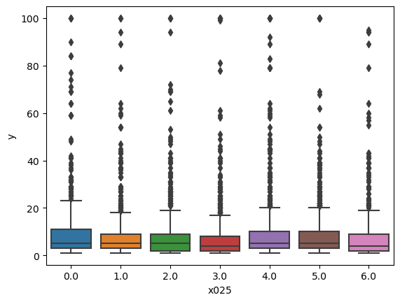

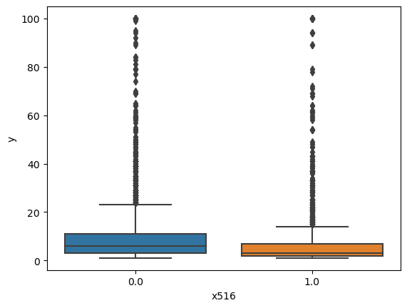

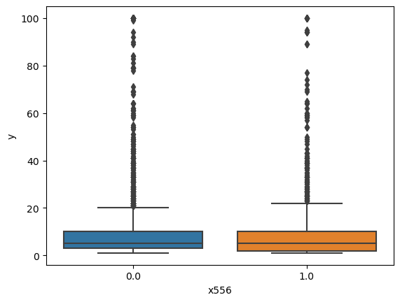

```python
sns.boxplot(x = X_imputed.x025, y = y)
plt.show()
sns.boxplot(x = X_imputed.x516, y = y)
plt.show()
sns.boxplot(x = X_imputed.x556, y = y)
plt.show()
```

## A.3) Feature selection/reduction

Mention the steps for feature selection/reduction. PLease put your code or visualizations here if needed. - Used a correlation matrix of all features to identify collinear predictors. Removed predictors with high collinearity (over 0.95 correlation coefficient with at least one other feature). - Used an untuned catboost model with the select_features() method to identify and keep the 50 most important remaining features, removing all others. - After obtaining the final predictor set, I scaled the data.

```python
corr_triu = np.triu(X_imputed.corr())
corr_triu
```

```
array([[ 1.        , -0.1032223 ,  0.1549608 , ...,  0.62700385,
        -0.15022717, -0.07129993],
       [ 0.        ,  1.        , -0.17774081, ...,  0.01797236,
         0.81943665, -0.01524231],
       [ 0.        ,  0.        ,  1.        , ...,  0.2040871 ,
        -0.50092743, -0.04305547],
       ...,
       [ 0.        ,  0.        ,  0.        , ...,  1.        ,
        -0.14165107, -0.09568018],
       [ 0.        ,  0.        ,  0.        , ...,  0.        ,
         1.        ,  0.0054187 ],
       [ 0.        ,  0.        ,  0.        , ...,  0.        ,
         0.        ,  1.        ]])
```

```python
corrs = np.sum(corr_triu > 0.95, axis = 1)
col_corr = pd.DataFrame({'col': X_imputed.columns, 'corr': (corrs > 1)})
col_corr.head()
```

|  | col | corr |
| --- | --- | --- |
| 0 | x001 | True |
| 1 | x002 | True |
| 2 | x003 | False |
| 3 | x004 | True |
| 4 | x005 | True |

```python
to_drop = col_corr[col_corr['corr'] == True]
print(len(to_drop))
to_drop = to_drop.col.tolist()
```

```
384
```

```python
X_nocorr = X_imputed.drop(to_drop, axis = 1)
X_nocorr.shape
```

```
(5380, 370)
```

```python
catboost_select = CatBoostRegressor(verbose = False, random_state = 0)
X_train, X_test, y_train, y_test = train_test_split(X_nocorr, y, test_size = 0.2, random_state = 0)
feat_importances = catboost_select.select_features(X_train, y_train, eval_set = (X_test, y_test),
                                                   features_for_select = X_nocorr.columns,
                                                   num_features_to_select = 50,
                                                   steps = 3, plot = True, verbose = False)
```

```python
X_cat_feats = X_nocorr.drop(feat_importances['eliminated_features_names'], axis = 1)
X_cat_feats.shape
```

[output not shown]

```python
scaler = StandardScaler()
X_cat_scaled = scaler.fit_transform(X_cat_feats)
```

## A.4) Developing the model

Mention the logical sequence of steps taken to obtain the final model.

- The first model was a basic MARS model.
- The second model was an untuned catboost model. Catboost grid searching seems to take longer so I did not tune its hyperparameter grid, instead relying on the ensemble to reduce variance.
- The third and fourth models were XGBoost and LGBM, which I grid searched to find the optimal hyperparameter combinations.
- The final model was a bagged catboost model, aiming to reduce variance with bootstrapping.

I ensembled the above models to create the final model. Examining the mean residuals of the model on training data, the model seems to under-predict the values, so I added 2 to the final test predictions to compensate for this tendency, which vastly improved its test performance.

```python
mars = Earth(max_terms = 500, max_degree = 1)
mars.fit(X_cat_feats, y)
print(mars.summary())
```

[output not shown]

```python
xgb = XGBRegressor(random_state = 1)
start_time = time.time()
param_grid = {'max_depth': [4,6,8],
              'learning_rate': [0.01, 0.05, 0.1],
               'reg_lambda':[0, 1, 10],
                'n_estimators':[100, 400, 600],
                'gamma': [0, 10, 100],
                'subsample': [0.5, 0.7],
                'colsample_bytree': [0.5, 0.75, 1.0]}

cv = KFold(n_splits=3,shuffle=True,random_state=1)
optimal_params = RandomizedSearchCV(estimator=XGBRegressor(random_state = 1),
                             param_distributions = param_grid, n_iter = 50,
                             verbose = 1,
                             n_jobs=-1,
                             cv = cv, random_state = 1)
optimal_params.fit(X_cat_scaled,y_log)
print("Optimal parameter values =", optimal_params.best_params_)
print("Optimal cross validation R-squared = ",optimal_params.best_score_)
print("Time taken = ", round((time.time()-start_time)/60), " minutes")
```

[output not shown]

```python
start_time = time.time()
lgbm = LGBMRegressor(random_state = 1)
param_grid = {'max_depth': [4,6,8],
              'num_leaves': [10, 20, 31, 40],
              'learning_rate': [0.01, 0.02, 0.05],
               'reg_lambda':[0, 10, 100],
                'n_estimators':[100, 400, 600],
                'reg_alpha': [0, 10, 100],
                'subsample': [0.4, 0.5, 0.6],
                'colsample_bytree': [0.5, 0.75, 1.0]}

cv = KFold(n_splits=3,shuffle=True,random_state=1)
grid = RandomizedSearchCV(estimator=LGBMRegressor(random_state=1),
                             param_distributions = param_grid,
                            n_iter = 500,
                             verbose = 1,
                             n_jobs=-1,
                             cv = cv, scoring = 'neg_root_mean_squared_error',
                          random_state = 0
                    )
grid.fit(X_cat_scaled, y_log)
print(grid.best_score_)
print(grid.best_params_)
print("Time taken = ", round((time.time()-start_time)/60), " minutes")
```

[output not shown]

```python
cat = CatBoostRegressor(verbose = False, random_state = 0)
cat_bag = BaggingRegressor(estimator = cat, max_samples = 0.75,
                           random_state = 0,
                           verbose = 1, n_jobs = -1)
```

```python
catboost = CatBoostRegressor(random_state = 0, verbose = False)
xgb = XGBRegressor(random_state = 0, subsample = 0.7, reg_lambda = 1,
                   n_estimators = 600, max_depth = 6, learning_rate = 0.01)
lgbm = LGBMRegressor(random_state = 0, subsample = 0.5, reg_lambda = 10,
                     reg_alpha = 0, num_leaves = 20, n_estimators = 400,
                     max_depth = 6, learning_rate = 0.05,
                     colsample_bytree = 0.5)
```

```python
start_time = time.time()
en = StackingRegressor(estimators = [('catboost', catboost),('xgb', xgb), ('lgbm', lgbm), ('cat_bag', cat_bag), ('mars', mars)],
                     final_estimator=LinearRegression(),
                    cv = KFold(n_splits = 5, shuffle = True, random_state=1))
en.fit(X_cat_scaled,y_log)
print("Time taken = ", round((time.time()-start_time)/60), " minutes")
```

```python
resids = np.exp(en.predict(X_cat_scaled)) - y
add_resid = np.mean(resids)
add_resid
```

[output not shown]

```python
test = pd.read_csv('test.csv')
id = test['id']
test.drop(['id'], axis=1, inplace=True)
test_imputed = pd.DataFrame(imputer.transform(test), columns=test.columns)
test_imputed.drop(zero_var, axis=1, inplace=True)
test_imputed.drop(to_drop, axis=1, inplace=True)
test_imputed.shape
test_cat_feats = test_imputed.drop(feat_importances['eliminated_features_names'], axis = 1)
test_cat_scaled = scaler.transform(test_cat_feats)
test_cat_scaled.shape
```

```python
y_pred_test = np.exp(en.predict(test_cat_scaled)) + 2
preds = pd.DataFrame({'id': id, 'y': y_pred_test})
plt.hist(preds['y'], bins=100)
plt.show()
preds.to_csv('ensemble4_log_2.csv', index=False)
```

[output not shown]

## A.5) Discussion

Please provide details of the models/approaches you attempted but encountered challenges or unfavorable outcomes. If feasible, kindly explain the reasons behind their ineffectiveness or lack of success. Additionally, highlight the significant challenges or issues you encountered during the process.

Random forest performed worse than expected, along with neural network approaches. This is likely due to time constraints as I was not able to devote as much attention to these approaches as I would have liked.

One of the most significant challenges in working on this problem was the necessity of fitting a parameter grid and letting it run for upwards of 10 to 20 minutes. This unnecessarily extended the length of work sessions.

## A.6) Conclusion

- Do you feel that you gain valuable experience, skills, and/or knowledge? If yes, please explain what they were. If no, please explain.
- What are things you liked/disliked about the project and/or work on the project?

Kaggle competitions (and data science problems in general) provide metadata that allow for extensive EDA in order to more concretely determine the best approach before even beginning modeling. Due to the anonymized data, this was not possible, making the experience of working on this problem difficult to translate to future work. With that said, the process of tuning and ensembling models was valuable.

The tedious nature of grid searching, while inevitable, should have been made smoother with better cloud computing resources or less demanding thresholds. The competitive nature of the grade cutoffs was also unfavorable to individuals like me who were not allowed to work with a team. It is not surprising that the top 390 submissions on the leaderboard are groups and not individuals.

## Please make sure your github repo has all the code and ensure that your code is capable of reproducing the outcomes you have submitted. It is important to avoid any form of academic misconduct or cheating by using your peer’s submission file